[figure not shown]

[Coastal barometer website](http://folk.ntnu.no/erlenfau/KystBaro/) | [Coastal barometer blog](https://kystbarometeret.com) | [Ocean health index](http://www.oceanhealthindex.org) | [Citation policy](http://ohi-science.org/citation-policy/)

# Calculation of fisheries sustainability score

Marina Espinasse

2020-11-06

```r
library(stringr)
library(ggthemes)
library(scales)
library(zoo)
library(ggridges)
library(kableExtra)
```

# 1 Importing formatted catches and stocks data

```r
stock_scores <- read.csv("data/stock_scores.csv")
catch <- read.csv("data/catch_total.csv")
seaarea <-read_excel(file.path(dir_M[2], "Fishery/DeliveryDataFiskDir/KommArea.xlsx"))
```

# 2 Merging catch data with ICES stocks data

```r
stock_scores_prep <- stock_scores[,-1]

fish_nor <-catch %>%
           left_join(stock_scores_prep,
                  by = c("Year", "English"
                  ))
```

Checking the number of data points per species

```r
fish_nor %>% group_by(English) %>%
            tally()
```

```
## # A tibble: 11 x 2
##    English               n
##    <chr>             <int>
##  1 Atlantic cod       1626
##  2 Atlantic herring    439
##  3 Atlantic mackerel   108
##  4 Blue whiting         78
##  5 Capelin             125
##  6 Greenland halibut   710
##  7 Haddock            1530
##  8 Kingcrab            224
##  9 Redfish            1432
## 10 Saithe             1567
## 11 Shrimp              491
```

# 3 Further data cleaning: removing and re-arranging locations

Deleting municipalities that are not in the study (Beiarn county and Guovdageaidnu-Kautokeino) Re-estimating landings for the municipalities that were merged (Bodo + Skjerstad_2005, Bjarkoy_2013 + Harstad_2013) - I sum the landings for these pairs of municipalities for the years before they’ve merged. Using this approach to merge catches will create duplicated rows, I remove them in the chunk after.

```r
fish_nor_prep <- fish_nor %>%
                  rename(Species = English) %>%
                  mutate(Municip_name = as.character(Municip_name)) %>%
                  filter(!Municip_name %in% c("Beiarn", "Guovdageaidnu-Kautokeino")) %>%
                  mutate(newid = case_when(Municip_name %in% c("Harstad_2013", "Bjarkoy_2013") ~ "1",
                                           Municip_name %in% c("Bodo", "Skjerstad_2005") ~ "2",
                                           TRUE ~ Municip_name)) %>%
                  group_by(newid, Year, Species) %>%
                  mutate(Total_catch_new = sum(Total_catch))
```

In this table, *Municip_name_new* are the names of the municipalities after they’ve merged. *Total_catch_new* is the total fish landings after municipalities merged.

```r
fish_nor_prep2 <- fish_nor_prep %>%
                  ungroup() %>%
                  select(-c("Municip_name", "Total_catch")) %>%
                  mutate(Municip_name_new = newid) %>%
                  mutate(Municip_name_new = replace(Municip_name_new, Municip_name_new == "1", "Harstad")) %>%
                  mutate(Municip_number = replace(Municip_number, Municip_name_new == "Harstad", "1903")) %>%
                  mutate(Municip_name_new = replace(Municip_name_new, Municip_name_new == "2", "Bodo")) %>%
                  mutate(Municip_number = replace(Municip_number, Municip_name_new == "Bodo", "1804")) %>%
                  distinct_all() %>%
                  select(-c(newid,  species_name))
```

# 4 Examining the distribution of observations of catches by species, regardless of municipality

This graph shows how the number of municipalities, where the catch was delivered, varied from 1994 to 2018

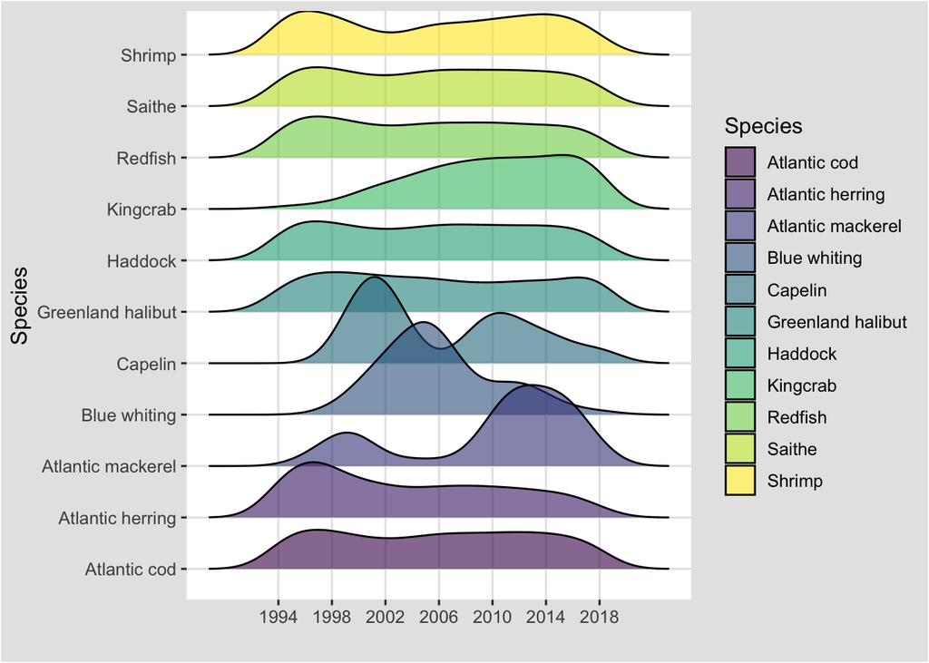

```r
catch_dist <- ggplot(data = fish_nor_prep2) +
  geom_density_ridges(aes(y = Species, x = Year, fill = Species)) +
  scale_x_continuous(breaks = seq(1994, 2018, 4)) +
  labs(x = "") +
  scale_fill_viridis_d(option = "D", alpha = 0.6) +
  theme_igray()
catch_dist
```

# 5 Estimating cacth per area and maximal weighted catch

(Check fisheries README. for details). This approach however, has a danger of positive outliers dominating the maximal catch per area. Due to multiple reasons, catch will vary in every municipality for each stock from year to year. Thus, a maximal catch (biomass) per area can be just an outlier, a seldom seen very high catch. Therefore most of the biomass.area/max.biomass.area ratios are very low (75% are less than 0.6). The largest catch per sea area was observed in Øksnes in 2018, for Atlantic cod.

We do not have MSY-reference points for shrimp, but we can assume it is sustainable. https://www.hi.no/hi/temasider/arter/kyst-og-fjordreke Similarly, for Kingcrab, I will assume its catches sustainable.

I remove redfish, blue whiting and greenland halibut from the table. 17.02.2020 we decided not to include these three species into the Fisheries sub-goal.

Calculation catch weighted scores (proportional catch multiplied by the stock score).

```r
seaarea <- seaarea %>%
          mutate(Komnum = as.character(Komnum))

weighted_catch_score <- fish_nor_prep2 %>%
  filter(!Species %in%
    c(
      "Redfish",
      "Greenland halibut",
       "Blue whiting"
    )) %>%
  mutate(stock_score = replace(
    stock_score,
    Species == "Shrimp",
    1
  )) %>%
  mutate(stock_score = replace(
    stock_score,
    Species == "Kingcrab",
    1
  )) %>%
  left_join(seaarea[, c("Havflate", "Komnum")], by = c("Municip_number" = "Komnum")) %>%
  rename("Seaarea" = "Havflate") %>%
  mutate(catch_per_area = Total_catch_new / Seaarea) %>%
  group_by(Species) %>%
  mutate(max_catch_area = max(catch_per_area)) %>%
  ungroup() %>%
  mutate(weighted_catch =  catch_per_area / max_catch_area) %>%
  mutate(weighted_catch_score = weighted_catch * stock_score)
#Check the basic stats for weighted biomass score:
mosaic::fav_stats(weighted_catch_score$catch_per_area)
```

```
##  min     Q1 median   Q3    max mean   sd    n missing
##    0 0.0272  0.193 1.09 244232 1127 9813 6019       0
```

```r
#write.csv(weighted_catch_score, "data/area_weighted_catch_and_catchscore.csv", row.names = F )
```

# 6 Re-estimate weighted catch per area based on smoothed catches

## 6.1 Apply 3-years rolling mean on catch data

Rolling mean is a remedy against inter-annual variability in catches and against influential outliers. I apply 3-year rolling mean to catch data. However,rolling mean does not help to smooth variability in catches between the municipalities.

When we apply a rolling mean, some observations will become NA (those at the edges of the 3-year window), because `rollapply` function calculates means of 3 overlapping years. Out of 8330 observations of catch, 1086 will become NA. The NAs are the first and the last year of a dataframe, made by unique combination of species and municipality. Since, there is certainly a temporal increase the total catches (taking a mean of all would be wrong), the best is to replace NA with the closest non-NA value, for instance for year 1994, take the catch of year 1995. I will do that with a `zoo::na.fill` function.

A simple function, that takes a dataframe as an argument, checks the number of rows. It applies 3-years running mean only of dataframe has at least 6 rows of data, and does not change the values if there are less than 6 rows of data.

```r
runmean_on_df <- function(df, col){
  if (nrow(df) >= 6) {
    runmean <- rollapply(df[,col], width = 3, FUN = mean,  fill=list("extend"))
    df2 <-cbind(df, runmean)
  } else {
    runmean <-df[,col]
    df2 <-cbind(df, runmean)
  }
  df2
}
```

```r
municipalities <-unique(fish_nor_prep2$Municip_name_new)
species <-unique(fish_nor_prep2$Species)

splist <-list()
finallist <-list()
for (i in 1:length(municipalities))
  {
   mp <- municipalities[i]
   df.mp <- fish_nor_prep2 %>%
      filter(Municip_name_new == mp)
    for (j in 1:length(species))
     {
        sp <- species[j]
        df.sp <- df.mp %>%
            filter(Species == sp)

      #runmean <-data.frame(catch_runmean = rollapply(df.sp$Total_catch_new, width = 3, FUN = mean,  fill=NA))
      df.sp.runmean <- runmean_on_df(as.data.frame(df.sp), 14) #column 14 is Total_catch_new
      #df.sp.full <- bind_cols(df.sp, runmean)
      splist[[j]] <- df.sp.runmean
      smoothed_catches_spp <- do.call("rbind", splist)
      finallist[[i]] <-smoothed_catches_spp

    }

 }

smoothed_catches <- do.call("rbind", finallist) %>%
  rename(catch_runmean = runmean)
colSums(is.na(smoothed_catches))
```

```
##             Year   Municip_number          Species              SSB
##                0                0                0              765
##            Stock             Flim             Blim             Fmsy
##              765             2951             1470             3135
##      MSYBtrigger                F          b_score          f_score
##             2826              890             2826             4491
##      stock_score  Total_catch_new Municip_name_new    catch_runmean
##             2826                0                0                0
```

## 6.2 Re-esitmate weighted catch per area based on smoothed catches

```r
smoothed_weighted_catch_score <- smoothed_catches %>%
  filter(!Species %in%
    c(
      "Redfish",
      "Greenland halibut",
      "Blue whiting"
    )) %>%
  mutate(stock_score = replace(
    stock_score,
    Species == "Shrimp",
    1
  )) %>%
  mutate(stock_score = replace(
    stock_score,
    Species == "Kingcrab",
    1
  )) %>%
left_join(seaarea[, c("Havflate", "Komnum")], by = c("Municip_number" = "Komnum")) %>%
  rename("Seaarea" = "Havflate") %>%
  filter(!is.na(catch_runmean)) %>%
  mutate(catch_per_area = catch_runmean / Seaarea) %>%
  group_by(Year,Species) %>%
  mutate(max_catch_area = max(catch_per_area)) %>%
  ungroup() %>%
  mutate(weighted_catch = catch_per_area / max_catch_area) %>%
  mutate(weighted_catch_score = weighted_catch * stock_score)

#write.csv(smoothed_weighted_catch_score, "data/ smoothed_area_weighted_catch_and_catchscore.csv", row.names = F)
```

# 7 Check the distribution of biomass/area for each stock

## 7.1 Plot smoothed catches on a boxplot

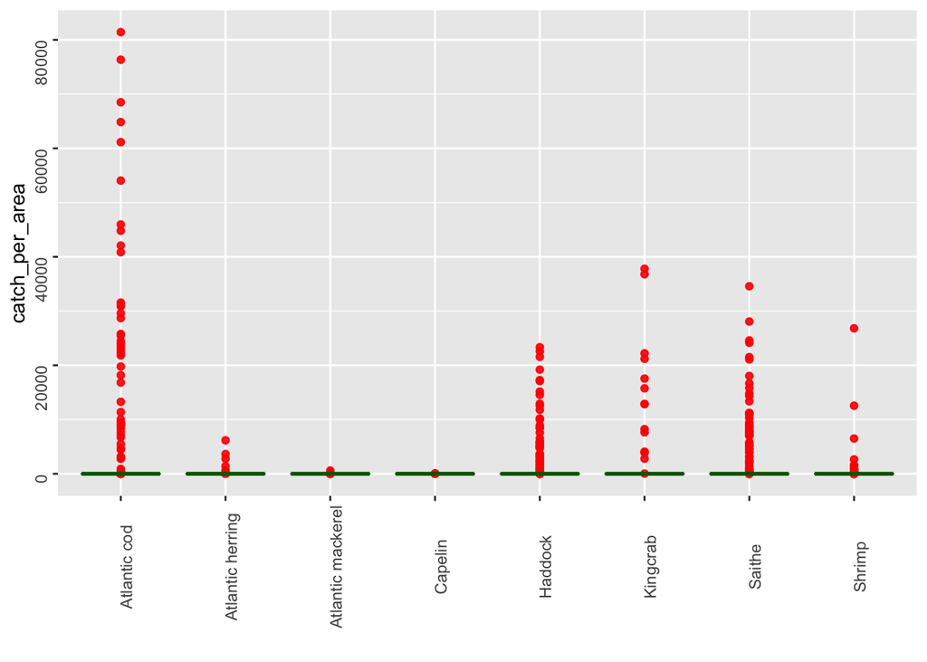

```r
plot2<- ggplot(smoothed_weighted_catch_score) +
  geom_boxplot(aes(Species, catch_per_area), color = "darkgreen", alpha = 0.7, fill = "transparent", outlier.color = "red") +
  labs(x = "") +
  theme(
  axis.text = element_text(angle = 90)
  )


#And a truncated version
plot3<- ggplot(smoothed_weighted_catch_score) +
  geom_boxplot(aes(Species, catch_per_area), color = "darkgreen", alpha = 0.7, fill = "transparent", outlier.color = "red") +
  scale_y_continuous(limits = c(0,30)) +
  labs(x = "") +
  theme(
    axis.text = element_text(angle = 90)
  )

plot2
```

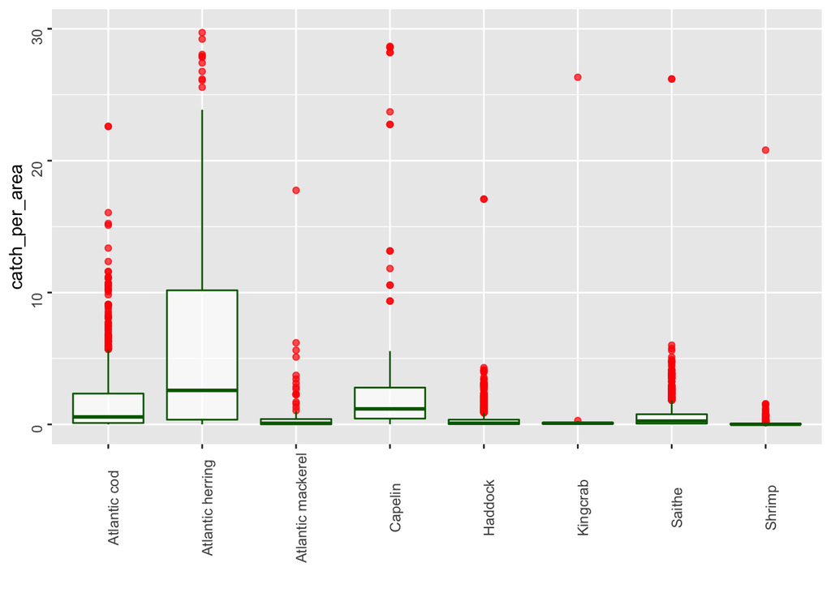

```r
plot3
```

## 7.2 Summarize smoothed catches in a table

```r
species <-unique(smoothed_weighted_catch_score$Species)

outputdf <- list()
for (i in 1:length(species))
  {
   sp <- species[i]
   spdf <- filter(smoothed_weighted_catch_score, Species == sp)
   stats <- mosaic::fav_stats(spdf$catch_per_area)
   allstats <-cbind(stats, Species = rep(sp, 1))
   outputdf[[i]] <- allstats
}

catch_area_favstats <- do.call("rbind", outputdf)

newtable <- catch_area_favstats %>%
    mutate(Species = cell_spec(
    Species, color = "white", bold = T,
    background = spec_color(1:8, end = 0.9, option = "A", direction = -1))) %>%
    mutate(max = round(max, 2)) %>%
    mutate(max = cell_spec(
    as.numeric(max), "html",
    color = ifelse(max > 1000, "red", "blue"))) %>%
    kable(escape = F, align = "c", digits = 4) %>%
    kable_styling(c("striped", "condensed"), full_width = F) %>%
    column_spec(1:10,bold = T,background = "azure", color = "darkgreen")
newtable
```

| min | Q1 | median | Q3 | max | mean | sd | n | missing | Species |
| --- | --- | --- | --- | --- | --- | --- | --- | --- | --- |
| 0.0001 | 0.1288 | 0.7859 | 2.8742 | 81419.4 | 1482.11 | 7628.1 | 1594 | 0 | Atlantic cod |
| 0.0000 | 0.4387 | 3.0968 | 11.8284 | 6174.45 | 77.48 | 526.5 | 438 | 0 | Atlantic herring |
| 0.0000 | 0.0213 | 0.1125 | 0.4412 | 23325.42 | 459.30 | 2350.6 | 1501 | 0 | Haddock |
| 0.0000 | 0.0716 | 0.3137 | 0.9974 | 34570.55 | 606.86 | 3002.4 | 1540 | 0 | Saithe |
| 0.0000 | 0.0026 | 0.0133 | 0.0724 | 26821.19 | 226.76 | 1942.9 | 489 | 0 | Shrimp |
| 0.0000 | 0.0126 | 0.0999 | 0.6866 | 592.78 | 17.71 | 85.8 | 108 | 0 | Atlantic mackerel |
| 0.0149 | 0.4816 | 1.3315 | 3.0012 | 66.96 | 5.08 | 11.0 | 125 | 0 | Capelin |
| 0.0000 | 0.0462 | 0.0972 | 0.1512 | 37795.83 | 1761.15 | 6244.0 | 224 | 0 | Kingcrab |

# 8 Calculate final fisheries scores based on smoothed weighted catches per area

```r
final_scores_smoothed_area <- smoothed_weighted_catch_score %>%
  group_by(Year, Municip_number, Municip_name_new) %>%
  mutate(total_tons = sum(catch_runmean)) %>%
  mutate(catch_prop = catch_runmean / total_tons) %>%
  mutate(fish_score = sum(weighted_catch_score * catch_prop * 100))
```

# 9 Quick-check of the distribution of area-weighted final score

```r
mosaic::fav_stats(final_scores_smoothed_area$fish_score)
```

```
##         min   Q1 median   Q3 max mean   sd    n missing
##  0.00000248 3.01   14.2 32.3 100 21.2 22.5 6019       0
```

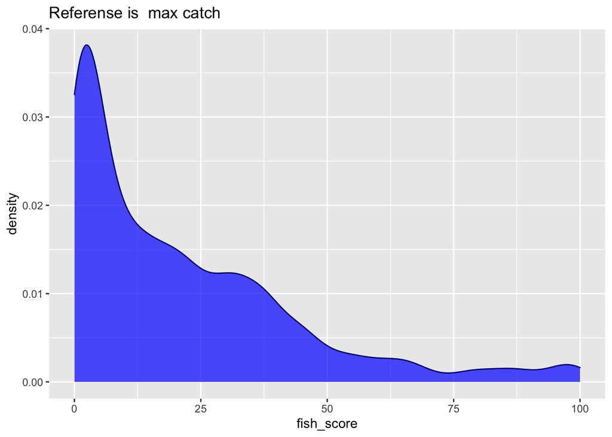

```r
plot1<- ggplot(final_scores_smoothed_area) +
        geom_density(aes(fish_score), fill = "blue", color = "navy", alpha = 0.7) +
  ggtitle("Referense is  max catch")
plot1
```

# 10 Using 0.75th quartile of catch per area as a target

```r
smoothed_weighted_catch_score_q75 <- smoothed_catches %>%
  filter(!Species %in%
    c(
      "Redfish",
      "Greenland halibut",
      "Blue whiting"
    )) %>%
  mutate(stock_score = replace(
    stock_score,
    Species == "Shrimp",
    1
  )) %>%
  mutate(stock_score = replace(
    stock_score,
    Species == "Kingcrab",
    1
  )) %>%
  left_join(seaarea[, c("Havflate", "Komnum")], by = c("Municip_number" = "Komnum")) %>%
  rename("Seaarea" = "Havflate") %>%
  filter(!is.na(catch_runmean)) %>%
  mutate(catch_per_area = catch_runmean / Seaarea) %>%
  group_by(Year,Species) %>%
  mutate(catch_area_q75 = quantile(catch_per_area, probs = 0.75)) %>%
  ungroup() %>%
  mutate(weighted_catch = ifelse(
    catch_per_area > catch_area_q75, 1, catch_per_area / catch_area_q75
  )) %>%
  mutate(weighted_catch_score = weighted_catch * stock_score)
```

# 11 Recalcualte fisheries score based on 0.75th quartile of catch as a reference

```r
final_scores_smoothed_area_q75 <- smoothed_weighted_catch_score_q75 %>%
                  group_by(Year, Municip_number, Municip_name_new) %>%
                  mutate(total_tons = sum(catch_runmean)) %>%
                  mutate(catch_prop = catch_runmean / total_tons) %>%
                  summarize(fish_score = sum(weighted_catch_score*catch_prop*100))
```

```r
smoothed_weighted_catch_score_q90 <- smoothed_catches %>%
  filter(!Species %in%
    c(
      "Redfish",
      "Greenland halibut",
      "Blue whiting"
    )) %>%
  mutate(stock_score = replace(
    stock_score,
    Species == "Shrimp",
    1
  )) %>%
  mutate(stock_score = replace(
    stock_score,
    Species == "Kingcrab",
    1
  )) %>%
  left_join(seaarea[, c("Havflate", "Komnum")], by = c("Municip_number" = "Komnum")) %>%
  rename("Seaarea" = "Havflate") %>%
  filter(!is.na(catch_runmean)) %>%
  mutate(catch_per_area = catch_runmean / Seaarea) %>%
  group_by(Year,Species) %>%
  mutate(catch_area_q90 = quantile(catch_per_area, probs = 0.90)) %>%
  ungroup() %>%
  mutate(weighted_catch = ifelse(
    catch_per_area > catch_area_q90, 1, catch_per_area / catch_area_q90
  )) %>%
  mutate(weighted_catch_score = weighted_catch * stock_score)
```

```r
final_scores_smoothed_area_q90 <- smoothed_weighted_catch_score_q90 %>%
                  group_by(Year, Municip_number, Municip_name_new) %>%
                  mutate(total_tons = sum(catch_runmean)) %>%
                  mutate(catch_prop = catch_runmean / total_tons) %>%
                  summarize(fish_score = sum(weighted_catch_score*catch_prop*100))
```

# 12 Quickly check the distribution of area-weighted final score based on 0.75th qunatile and 0.90 quantile

```r
mosaic::fav_stats(final_scores_smoothed_area_q75$fish_score)
```

```
##         min   Q1 median   Q3 max mean   sd    n missing
##  0.00000775 13.4     46 77.3 100 46.8 34.1 1676       0
```

```r
plot4<- ggplot(final_scores_smoothed_area_q75) +
        geom_density(aes(fish_score), fill = "blue", color = "navy", alpha = 0.7) +
  ggtitle("Referense is 75th quantile of max catch")
```

```r
mosaic::fav_stats(final_scores_smoothed_area_q90$fish_score)
```

```
##         min   Q1 median   Q3 max mean   sd    n missing
##  0.00000452 7.55   30.5 58.9 100 36.1 30.8 1676       0
```

```r
plot5<- ggplot(final_scores_smoothed_area_q90) +
        geom_density(aes(fish_score), fill = "blue", color = "navy", alpha = 0.7) +
  ggtitle("Referense is 90th quantile of max catch")
```

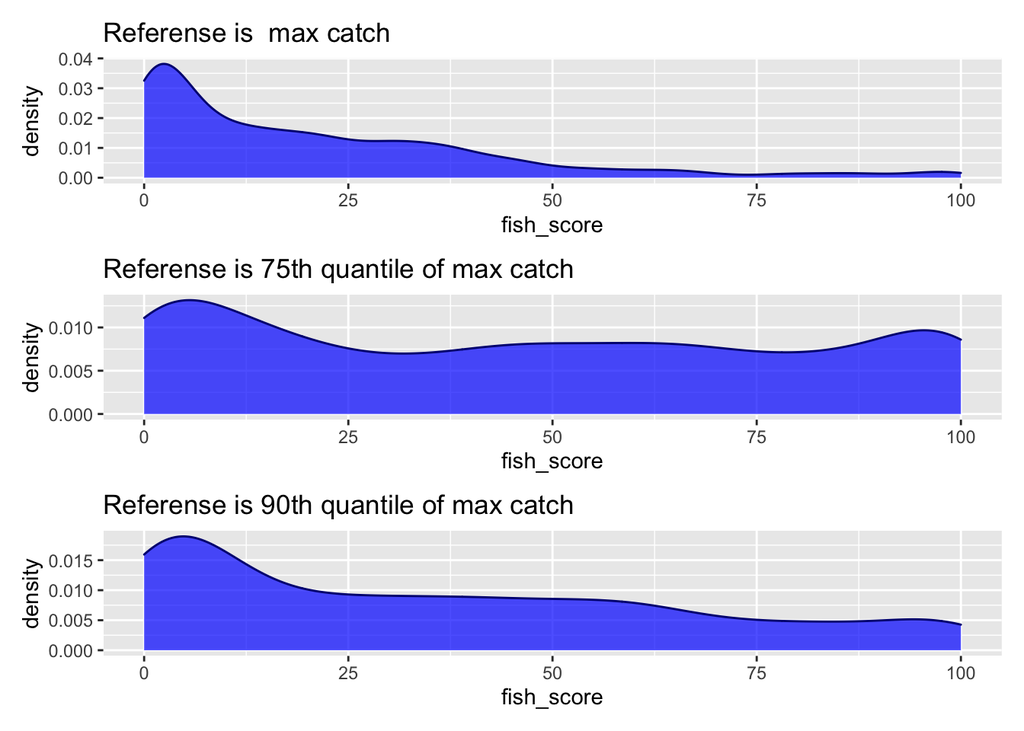

```r
library(patchwork)
plot1/plot4/plot5
```